# EDA on IMDb Movies Dataset

## IMDb Movies Dataset

This dataset includes information of IMDB Dataset of top 1000 movies in 2020.

### Data Source:

[IMDb Movies Dataset](https://www.kaggle.com/datasets/harshitshankhdhar/imdb-dataset-of-top-1000-movies-and-tv-shows/data)

### Data Content:

Total 16 columns, with 2 target variables **IMDB_Rating** and **Gross**.

- **Poster_Link** - Link of the poster that imdb using
- **Series_Title** - Name of the movie
- **Released_Year** - Year at which that movie released
- **Certificate** - Certificate earned by that movie
- **Runtime** - Total runtime of the movie
- **Genre** - Genre of the movie
- **IMDB_Rating** - Rating of the movie at IMDB site
- **Overview** - mini story/ summary
- **Meta_score** - Score earned by the movie
- **Director** - Name of the Director
- **Star1,Star2,Star3,Star4** - Name of the Stars
- **No_of_votes** - Total number of votes
- **Gross** - Money earned by that movie

## Exploration Data Analysis (EDA)

1) Obtain data from data source 2) Clean data to machine readable format 3) Explore data patterns using **seaborn** and **matpoltlib** 4) Train model to forecast **IMDB_Rating** and **Gross** 5) Interpret data patterns to solve **Task 1** and **Task 2**

### 1. Obtain data from data source

```python
import numpy as np
import pandas as pd
import seaborn as sns
import matplotlib.pyplot as plt
```

### Obtain data

```python
df = pd.read_csv("../DSproject/imdb_top_1000.csv.xls")
df.head(3)
```

|  | Poster_Link | Series_Title | Released_Year | Certificate | Runtime | Genre | IMDB_Rating | Overview | Meta_score | Director | Star1 | Star2 | Star3 | Star4 | No_of_Votes | Gross |
| --- | --- | --- | --- | --- | --- | --- | --- | --- | --- | --- | --- | --- | --- | --- | --- | --- |
| 0 | https://m.media-amazon.com/images/M/MV5BMDFkYT... | The Shawshank Redemption | 1994 | A | 142 min | Drama | 9.3 | Two imprisoned men bond over a number of years... | 80.0 | Frank Darabont | Tim Robbins | Morgan Freeman | Bob Gunton | William Sadler | 2343110 | 28,341,469 |
| 1 | https://m.media-amazon.com/images/M/MV5BM2MyNj... | The Godfather | 1972 | A | 175 min | Crime, Drama | 9.2 | An organized crime dynasty's aging patriarch t... | 100.0 | Francis Ford Coppola | Marlon Brando | Al Pacino | James Caan | Diane Keaton | 1620367 | 134,966,411 |
| 2 | https://m.media-amazon.com/images/M/MV5BMTMxNT... | The Dark Knight | 2008 | UA | 152 min | Action, Crime, Drama | 9.0 | When the menace known as the Joker wreaks havo... | 84.0 | Christopher Nolan | Christian Bale | Heath Ledger | Aaron Eckhart | Michael Caine | 2303232 | 534,858,444 |

### Overview data

```
<class 'pandas.core.frame.DataFrame'>
RangeIndex: 1000 entries, 0 to 999
Data columns (total 16 columns):
 #   Column         Non-Null Count  Dtype
---  ------         --------------  -----
 0   Poster_Link    1000 non-null   object
 1   Series_Title   1000 non-null   object
 2   Released_Year  1000 non-null   object
 3   Certificate    899 non-null    object
 4   Runtime        1000 non-null   object
 5   Genre          1000 non-null   object
 6   IMDB_Rating    1000 non-null   float64
 7   Overview       1000 non-null   object
 8   Meta_score     843 non-null    float64
 9   Director       1000 non-null   object
 10  Star1          1000 non-null   object
 11  Star2          1000 non-null   object
 12  Star3          1000 non-null   object
 13  Star4          1000 non-null   object
 14  No_of_Votes    1000 non-null   int64
 15  Gross          831 non-null    object
dtypes: float64(2), int64(1), object(13)
memory usage: 125.1+ KB
```

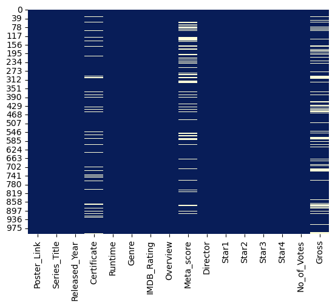

```python
#Find columns with missing data
df.info()
sns.heatmap(df.isna(), cbar=False, cmap="YlGnBu_r")
```

### 2. Clean data to machine readable format

### Handling missing data

1) Certificate, 2) Meta_score, 3) Gross

```python
df.loc[df.isna().any(axis=1), ['Certificate','Meta_score','Gross']]
```

|  | Certificate | Meta_score | Gross |
| --- | --- | --- | --- |
| 18 | PG-13 | 90.0 | NaN |
| 20 | U | NaN | NaN |
| 30 | NaN | 85.0 | NaN |
| 32 | PG | 89.0 | NaN |
| 46 | U | 94.0 | NaN |
| ... | ... | ... | ... |
| 993 | A | 82.0 | NaN |
| 995 | A | 76.0 | NaN |
| 996 | G | 84.0 | NaN |
| 998 | NaN | 78.0 | NaN |
| 999 | NaN | 93.0 | NaN |

286 rows × 3 columns

```python
#Drop rows without "Gross" value
#"Gross" is dependent variable, so I don't simply fill it
df = df[df['Gross'].notna()]
df.shape
```

```
(831, 16)
```

```python
#Fill NaN with mode and median
categorical_columns=df.select_dtypes(include=['object']).columns.tolist()
numerical_columns=df.select_dtypes(include=['int64','float64']).columns.tolist()
print("Categorical:",categorical_columns)
print("Numerical:",numerical_columns)

for column in df:
    if df[column].isnull().any():
        if(column in categorical_columns):
            df[column]=df[column].fillna(df[column].mode()[0])
        else:
            df[column]=df[column].fillna(df[column].median())
```

```
Categorical: ['Poster_Link', 'Series_Title', 'Released_Year', 'Certificate', 'Runtime', 'Genre', 'Overview', 'Director', 'Star1', 'Star2', 'Star3', 'Star4', 'Gross']
Numerical: ['IMDB_Rating', 'Meta_score', 'No_of_Votes']
```

```
<class 'pandas.core.frame.DataFrame'>
Index: 831 entries, 0 to 997
Data columns (total 16 columns):
 #   Column         Non-Null Count  Dtype
---  ------         --------------  -----
 0   Poster_Link    831 non-null    object
 1   Series_Title   831 non-null    object
 2   Released_Year  831 non-null    object
 3   Certificate    831 non-null    object
 4   Runtime        831 non-null    object
 5   Genre          831 non-null    object
 6   IMDB_Rating    831 non-null    float64
 7   Overview       831 non-null    object
 8   Meta_score     831 non-null    float64
 9   Director       831 non-null    object
 10  Star1          831 non-null    object
 11  Star2          831 non-null    object
 12  Star3          831 non-null    object
 13  Star4          831 non-null    object
 14  No_of_Votes    831 non-null    int64
 15  Gross          831 non-null    object
dtypes: float64(2), int64(1), object(13)
memory usage: 110.4+ KB
```

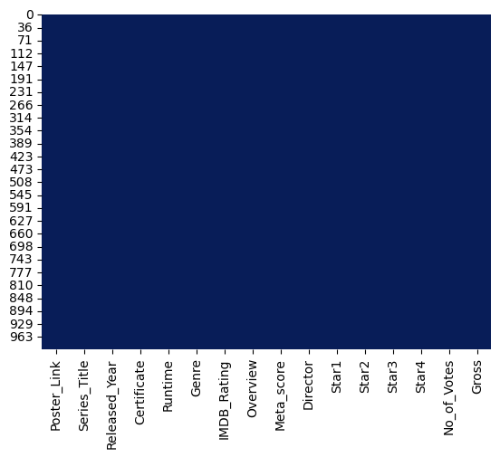

```python
#Review data after cleaning
df.info()
sns.heatmap(df.isna(), cbar=False, cmap="YlGnBu_r")
```

### Generate new column

1) Principal_Genre

```python
df['Principal_Genre'] = df['Genre'].apply(lambda x: x.split(',')[0])
df[['Genre','Principal_Genre']].loc[:5,:]
```

|  | Genre | Principal_Genre |
| --- | --- | --- |
| 0 | Drama | Drama |
| 1 | Crime, Drama | Crime |
| 2 | Action, Crime, Drama | Action |
| 3 | Crime, Drama | Crime |
| 4 | Crime, Drama | Crime |
| 5 | Action, Adventure, Drama | Action |

### Fix data types

1) Certificate, 2) Principal_Genre, 3) Released_Year, 4) Runtime (min), 5) Gross (mil $)

```python
#Check object variables with <20 of unique categories
df1 = pd.DataFrame(df.select_dtypes(include=['object']).nunique()).transpose()
df1.loc[:,df1.loc[0,:]<20]
```

|  | Certificate | Principal_Genre |
| --- | --- | --- |
| 0 | 13 | 13 |

```python
#Convert "Certificate" from object to category
df['Certificate'] = df['Certificate'].astype('category')

#Convert "Principal_Genre" from object to category
df['Principal_Genre'] = df['Principal_Genre'].astype('category')

#Drop rows with non-digit in "Released_Year"
for ind, value in df['Released_Year'].items():
    if value.isdigit() != True:
        print(df.loc[ind,['Released_Year']])
        df.drop(ind, inplace=True)
        print("\nIndex",ind,"is dropped because it has non-digit.\n")

#Convert "Released_Year" from object to int
df['Released_Year'] = df['Released_Year'].astype('int')

#Convert 'Runtime' from object to int
df['Runtime'] = df['Runtime'].apply(lambda x: x.split(" ")[0])
df.rename({'Runtime':'Runtime (min)'}, axis=1, inplace=True)
df['Runtime (min)'] = df['Runtime (min)'].astype('int')

#Convert 'Gross' from object to int
df['Gross'] = df['Gross'].loc[df['Gross'].notna()].apply(lambda x: x.replace(',',''))
df['Gross'] = df['Gross'].astype('int')
df['Gross'] = df['Gross']/1e6
df.rename({'Gross':'Gross (mil $)'}, axis=1, inplace=True)

df.info()
```

```
Released_Year    PG
Name: 966, dtype: object

Index 966 is dropped because it has non-digit.

<class 'pandas.core.frame.DataFrame'>
Index: 830 entries, 0 to 997
Data columns (total 17 columns):
 #   Column           Non-Null Count  Dtype
---  ------           --------------  -----
 0   Poster_Link      830 non-null    object
 1   Series_Title     830 non-null    object
 2   Released_Year    830 non-null    int64
 3   Certificate      830 non-null    category
 4   Runtime (min)    830 non-null    int64
 5   Genre            830 non-null    object
 6   IMDB_Rating      830 non-null    float64
 7   Overview         830 non-null    object
 8   Meta_score       830 non-null    float64
 9   Director         830 non-null    object
 10  Star1            830 non-null    object
 11  Star2            830 non-null    object
 12  Star3            830 non-null    object
 13  Star4            830 non-null    object
 14  No_of_Votes      830 non-null    int64
 15  Gross (mil $)    830 non-null    float64
 16  Principal_Genre  830 non-null    category
dtypes: category(2), float64(3), int64(3), object(9)
memory usage: 106.7+ KB
```

### Drop unuseful columns

1) Poster_Link, 2) Genre, 3) Overview

```python
print("Before drop: ", df.shape)
df = df.drop(['Poster_Link','Genre','Overview'], axis=1)
print("After drop: ", df.shape)
```

```
Before drop:  (830, 17)
After drop:  (830, 14)
```

### 3. Explore data patterns using **seaborn** and **matpoltlib**

### Dependent variables

1) IMDB_Rating, 2) Gross

[figure not shown]

```python
f, [ax0,ax1] = plt.subplots(1,2,figsize=(20,6))
sns.set_theme()
sns.histplot(df, x="IMDB_Rating", kde=True, ax=ax0)
ax0.set_title("IMDB_Rating", fontsize=14, fontweight='bold')

sns.histplot(df, x="Gross (mil $)", kde=True, ax=ax1, log_scale=True)
ax1.set_title("Gross (mil $)", fontsize=14, fontweight='bold')

#df.loc[df["IMDB_Rating"]>8.9,"Principal_Genre"]   #Top 5 IMBD rating movies are drama, crime and action genres.
#df.loc[df["Gross (mil $)"]>600,"Principal_Genre"] #Top 5 gross earning movies are action genre.
```

```python
max(df['Gross (mil $)'])
```

```
936.662225
```

### Relation of independent variables (numerical) to dependent

1) Released_Year, 2) Runtime (min), 3) Meta_score, 4) No_of_Votes

```python
df.select_dtypes(include=['int64','float64']).drop(["IMDB_Rating","Gross (mil $)"],axis=1).loc[:5,:]
```

|  | Released_Year | Runtime (min) | Meta_score | No_of_Votes |
| --- | --- | --- | --- | --- |
| 0 | 1994 | 142 | 80.0 | 2343110 |
| 1 | 1972 | 175 | 100.0 | 1620367 |
| 2 | 2008 | 152 | 84.0 | 2303232 |
| 3 | 1974 | 202 | 90.0 | 1129952 |
| 4 | 1957 | 96 | 96.0 | 689845 |
| 5 | 2003 | 201 | 94.0 | 1642758 |

```python
def scatterplots(df, num_feature):
    f, [ax0,ax1] = plt.subplots(1,2,figsize=(20,6))
    sns.scatterplot(data=df, x=num_feature, y="IMDB_Rating", ax=ax0, hue="Principal_Genre", legend=False)
    sns.regplot(data=df, x=num_feature, y="IMDB_Rating", ax=ax0, scatter=False)
    ax0.set_title("IMDB_Rating vs {}".format(num_feature), fontsize=14, fontweight='bold')

    sns.scatterplot(data=df, x=num_feature, y="Gross (mil $)", ax=ax1, hue="Principal_Genre")
    sns.regplot(data=df, x=num_feature, y="Gross (mil $)", ax=ax1, scatter=False)
    ax1.set_title("Gross (mil $) vs {}".format(num_feature),fontsize=14, fontweight='bold')
    ax1.legend(loc='best', ncol=2, handlelength=0.5)
    return
```

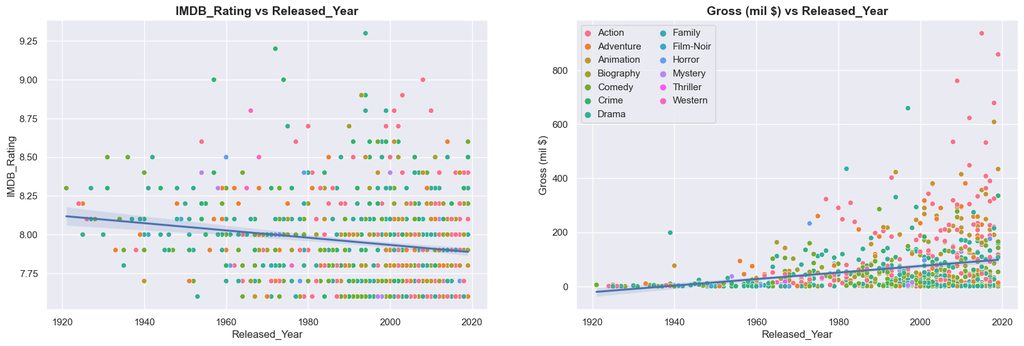

```python
scatterplots(df, "Released_Year")
```

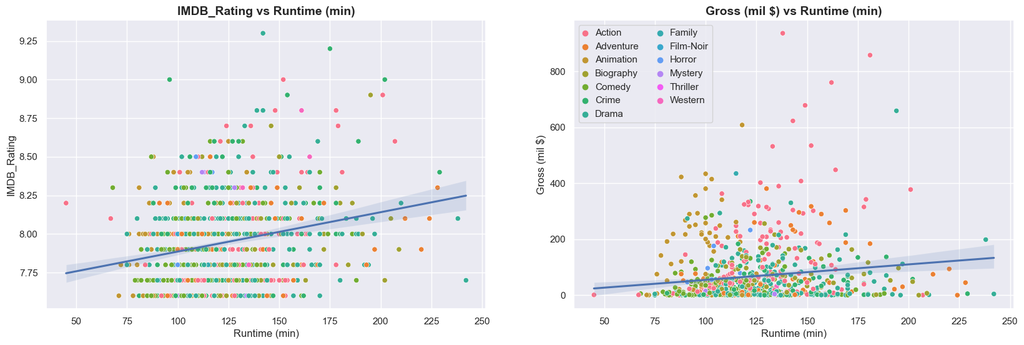

```python
scatterplots(df, "Runtime (min)")
```

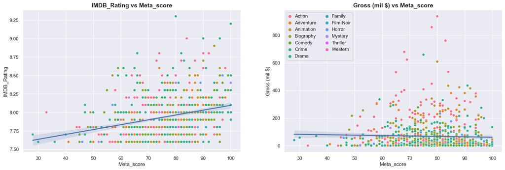

```python
scatterplots(df, "Meta_score")
```

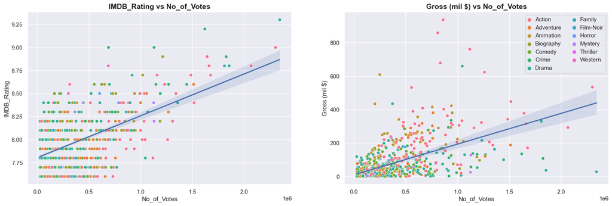

```python
scatterplots(df, "No_of_Votes")
```

###### Remark:

1) "IMDB Rating" is highly related to "No of Votes", then "Meta score". 2) "Gross" is also highly related to "No of Votes", but "Meta score" has no relation.

### Relation of independent variables (categorical) to dependent

1) Certificate, 2) Director, 3) Star1, 4) Star2, 5) Star3, 6) Star4, 7) Principal_Genre

```python
df.select_dtypes(include=['category','object']).drop(columns="Series_Title").loc[:5,:]
```

|  | Certificate | Director | Star1 | Star2 | Star3 | Star4 | Principal_Genre |
| --- | --- | --- | --- | --- | --- | --- | --- |
| 0 | A | Frank Darabont | Tim Robbins | Morgan Freeman | Bob Gunton | William Sadler | Drama |
| 1 | A | Francis Ford Coppola | Marlon Brando | Al Pacino | James Caan | Diane Keaton | Crime |
| 2 | UA | Christopher Nolan | Christian Bale | Heath Ledger | Aaron Eckhart | Michael Caine | Action |
| 3 | A | Francis Ford Coppola | Al Pacino | Robert De Niro | Robert Duvall | Diane Keaton | Crime |
| 4 | U | Sidney Lumet | Henry Fonda | Lee J. Cobb | Martin Balsam | John Fiedler | Crime |
| 5 | U | Peter Jackson | Elijah Wood | Viggo Mortensen | Ian McKellen | Orlando Bloom | Action |

```python
def boxplots_sorted_by_yvals(df, catg_feature, sort_by_target1, sort_by_target2):

    df_by_catg   = df.groupby([catg_feature])
    sortedlist1 = df_by_catg[sort_by_target1].median().sort_values().keys().tolist()
    sortedlist2 = df_by_catg[sort_by_target2].median().sort_values().keys().tolist()

    f, [ax0,ax1] = plt.subplots(1,2,figsize=(16,6))
    sns.boxplot(data=df, x=catg_feature, y="IMDB_Rating", ax=ax0, order=sortedlist1[-15:])
    ax0.set_xticklabels(ax0.get_xticklabels(),rotation = 45)
    ax0.set_title("IMDB_Rating vs {}".format(catg_feature), fontsize=14, fontweight='bold')

    sns.boxplot(data=df, x=catg_feature, y="Gross (mil $)", ax=ax1, order=sortedlist2[-15:])
    ax1.set_xticklabels(ax1.get_xticklabels(),rotation = 45)
    ax1.set_title("Gross (mil $) vs {}".format(catg_feature), fontsize=14, fontweight='bold')
    return [sortedlist1, sortedlist2]
```

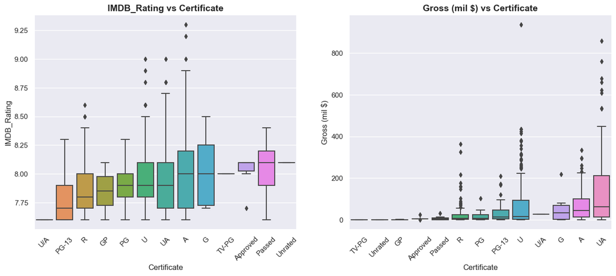

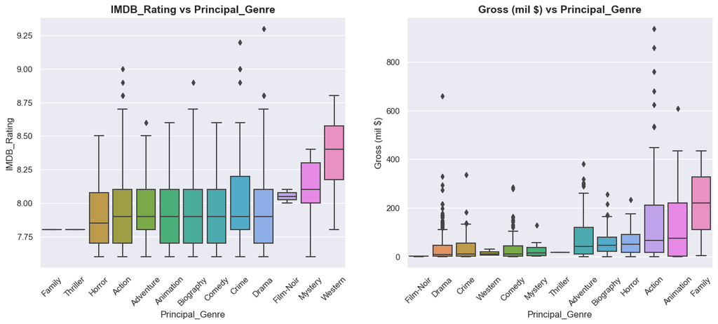

```python
[Cert_list1, Cert_list2] = boxplots_sorted_by_yvals(df, "Certificate", "IMDB_Rating", "Gross (mil $)")
[PGenre_list1, PGenre_list2] = boxplots_sorted_by_yvals(df, "Principal_Genre", "IMDB_Rating", "Gross (mil $)")
```

##### Remark:

1) "Certificate" such as U, UA, A and G are indication of good "IMDB Rating" and "Gross". 2) "Principal Genre" highly relates to "Gross", but not "IMDB Rating". Movies with principal genres such as action, animation and family usually associate higher gross earning.

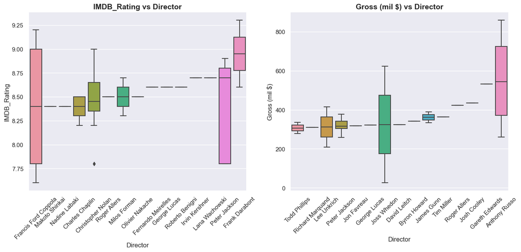

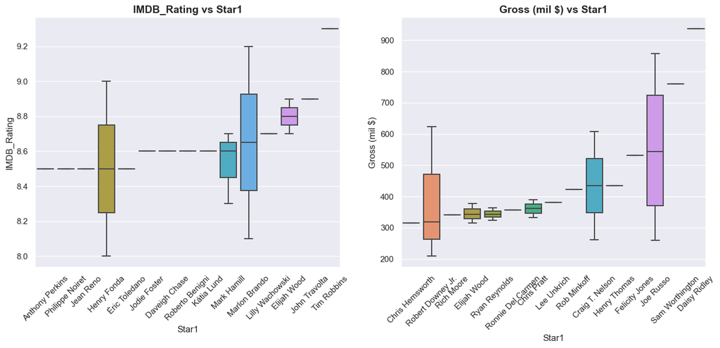

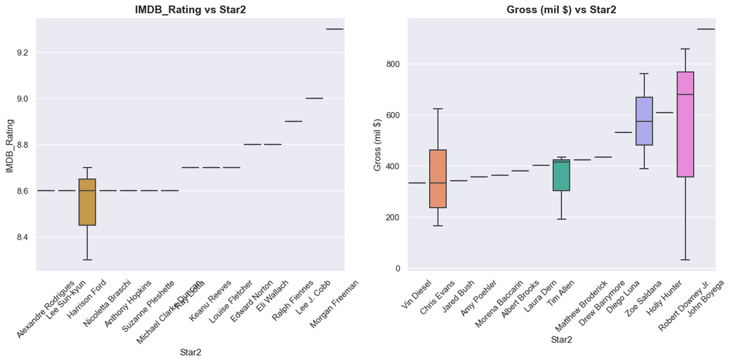

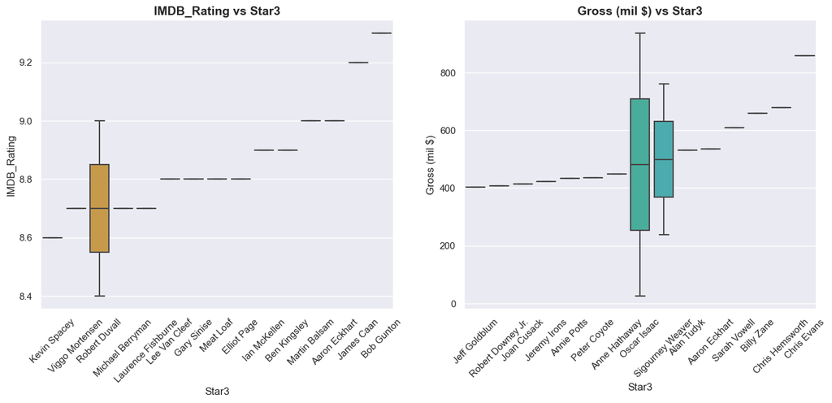

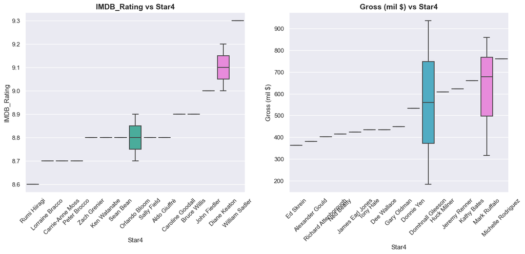

```python
[Director_list1, Director_list2] = boxplots_sorted_by_yvals(df, "Director", "IMDB_Rating", "Gross (mil $)")
[Star1_list1, Star1_list2] = boxplots_sorted_by_yvals(df, "Star1", "IMDB_Rating", "Gross (mil $)")
[Star2_list1, Star2_list2] = boxplots_sorted_by_yvals(df, "Star2", "IMDB_Rating", "Gross (mil $)")
[Star3_list1, Star3_list2] = boxplots_sorted_by_yvals(df, "Star3", "IMDB_Rating", "Gross (mil $)")
[Star4_list1, Star4_list2] = boxplots_sorted_by_yvals(df, "Star4", "IMDB_Rating", "Gross (mil $)")
```

##### Remark:

1) Generally, directors and stars (regardless of star 1,2,3,4) have significant impacts on both "IMDB Rating" and "Gross" earning. Compared to directors, stars have higher relation to high "IMDB Rating" and "Gross" earning. 2) The director in movie with highest "IMDB Rating" doesn't guarantee the highest "Gross" earning of movie. Similar cases go to stars.

### Data wrangling for correlation matrix

- #### Target: IMDB_Rating

```python
def label_catg(num, sorted_list, catg_feature, new_feature):
    for item in sorted_list:
        df.loc[(df[catg_feature] == item ), new_feature] = num
        num=num+1
    return

def plot_corr_matrix(df, nr_c, targ) :

    corr = df.corr()
    corr_abs = corr.abs()
    cols = corr_abs.nlargest(nr_c, targ)[targ].index
    cm = np.corrcoef(df[cols].values.T)
    mask = np.triu(np.ones_like(cm, dtype=bool))

    plt.figure(figsize=(nr_c/2, nr_c/2))
    sns.set(font_scale=1)
    sns.heatmap(cm, mask=mask, linewidths=2, annot=True, square=True,
                fmt='.2f', annot_kws={'size': 10},
                yticklabels=cols.values, xticklabels=cols.values
               )
    plt.show()
    return cols
```

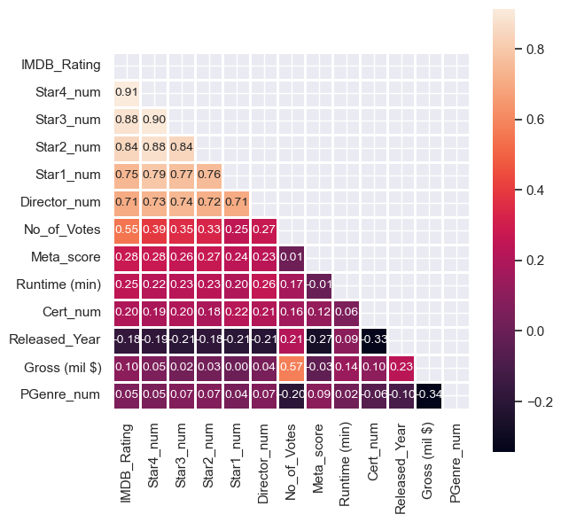

```python
#Label categorical feature with numbers
label_catg(1, Cert_list1, "Certificate", "Cert_num")
label_catg(1, PGenre_list1, "Principal_Genre", "PGenre_num")
label_catg(1, Director_list1, "Director", "Director_num")
label_catg(1, Star1_list1, "Star1", "Star1_num")
label_catg(1, Star2_list1, "Star2", "Star2_num")
label_catg(1, Star3_list1, "Star3", "Star3_num")
label_catg(1, Star4_list1, "Star4", "Star4_num")

#Drop non-numerical features
df_copy1 = df.drop(columns=['Series_Title','Certificate','Director','Star1','Star2','Star3','Star4','Principal_Genre'])

#Correlation Matrix
nr_feats=len(df_copy1.columns)
corr_list1 = plot_corr_matrix(df_copy1, nr_feats, "IMDB_Rating")
```

##### Remark:

1) The most correlated factors to "IMDB Rating" in descending order: Supporting roles, leading role, director and no of votes.

### Data wrangling for correlation matrix

- #### Target: Gross (mil $)

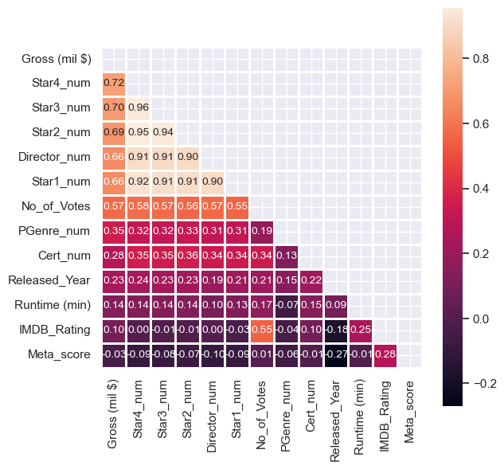

```python
#Label categorical feature with numbers
label_catg(1, Cert_list2, "Certificate", "Cert_num")
label_catg(1, PGenre_list2, "Principal_Genre", "PGenre_num")
label_catg(1, Director_list2, "Director", "Director_num")
label_catg(1, Star1_list2, "Star1", "Star1_num")
label_catg(1, Star2_list2, "Star2", "Star2_num")
label_catg(1, Star3_list2, "Star3", "Star3_num")
label_catg(1, Star4_list2, "Star4", "Star4_num")

#Drop non-numerical features
df_copy2 = df.drop(columns=['Series_Title','Certificate','Director','Star1','Star2','Star3','Star4','Principal_Genre'])

#Correlation Matrix
nr_feats=len(df_copy2.columns)
corr_list2 = plot_corr_matrix(df_copy2, nr_feats, "Gross (mil $)")
```

##### Remark:

1) The most correlated factors to gross earning in descending order: Supporting roles, director, leading role and no of votes.

### 4. Train model to forecast **IMDB_Rating** and **Gross**

```python
from sklearn.linear_model import LinearRegression
model = LinearRegression()

columns = ['Star4_num','Star3_num','Star2_num','Star1_num','Director_num','No_of_Votes','Meta_score','Runtime (min)','Cert_num','Released_Year','PGenre_num']

X = df[columns]
y= df['IMDB_Rating']
#y= df['Gross (mil $)']

model.fit(X,y)
model.score(X,y) #For better accuracy prediction, more datasets shall be included in training model.
```

```
0.59930068942258
```

##### Remark:

1. "Star1", "Star2", "Star3", "Star4" and "Director" have higher correlation to target variables. However, each star or director only appeared one to few times among the 830 data rows. For better forecast of "IMDB Rating" and "Gross", more datasets shall be included to train model.

### 5. Interpret data patterns to solve **Task 1** and **Task 2**

### Task 1 : What type of movies are getting good rating and gross amount?

```python
pd.DataFrame(zip(corr_list1, corr_list2),columns=[corr_list1[0], corr_list2[0]]).drop([0])
```

|  | IMDB_Rating | Gross (mil $) |
| --- | --- | --- |
| 1 | Star4_num | Star4_num |
| 2 | Star3_num | Star3_num |
| 3 | Star2_num | Star2_num |
| 4 | Star1_num | Director_num |
| 5 | Director_num | Star1_num |
| 6 | No_of_Votes | No_of_Votes |
| 7 | Meta_score | PGenre_num |
| 8 | Runtime (min) | Cert_num |
| 9 | Cert_num | Released_Year |
| 10 | Released_Year | Runtime (min) |
| 11 | Gross (mil $) | IMDB_Rating |
| 12 | PGenre_num | Meta_score |

##### Remark:

1) To get good rating and gross amount, movie cast is the most important especially supporting roles. Second, the public reputation of director is another huge factor. Lastly, no. of votes shall give a very good indication.

### **Task 2 : Mention the top 5 movies names according to different genres.**

```python
copy = df.set_index('Series_Title')
pd.DataFrame(copy.groupby("Principal_Genre")['Star4_num'].nlargest(5))
#pd.DataFrame(copy.groupby("Principal_Genre")['Director_num'].nlargest(5))
#pd.DataFrame(copy.groupby("Principal_Genre")['No_of_Votes'].nlargest(5))

#copy[copy['Star4_num']==781] #Show a movie list of the top star
#copy[copy['Director_num']==472] #Show a movie list of the top director
```

| Principal_Genre | Series_Title | Star4_num |
| --- | --- | --- |
| Action | Avatar | 781.0 |
|  | Avengers: Endgame | 780.0 |
|  | Avengers: Infinity War | 780.0 |
|  | Thor: Ragnarok | 780.0 |
|  | The Avengers | 778.0 |
| Adventure | Harry Potter and the Deathly Hallows: Part 2 | 764.0 |
|  | Harry Potter and the Sorcerer's Stone | 755.0 |
|  | The Hobbit: An Unexpected Journey | 751.0 |
|  | Harry Potter and the Goblet of Fire | 746.0 |
|  | Jaws | 739.0 |
| Animation | Incredibles 2 | 777.0 |
|  | Toy Story 4 | 772.0 |
|  | The Lion King | 771.0 |
|  | Toy Story 3 | 770.0 |
|  | Finding Nemo | 768.0 |
| Biography | The Blind Side | 735.0 |
|  | Bohemian Rhapsody | 714.0 |
|  | Hidden Figures | 688.0 |
|  | Catch Me If You Can | 684.0 |
|  | The Pursuit of Happyness | 683.0 |
| Comedy | Home Alone | 744.0 |
|  | The Hangover | 743.0 |
|  | Knives Out | 685.0 |
|  | The Sting | 678.0 |
|  | La La Land | 674.0 |
| Crime | Joker | 762.0 |
|  | Ocean's Eleven | 694.0 |
|  | The Green Mile | 665.0 |
|  | The Departed | 663.0 |
|  | The Silence of the Lambs | 659.0 |
| Drama | Titanic | 779.0 |
|  | Forrest Gump | 759.0 |
|  | The Sixth Sense | 749.0 |
|  | Gravity | 742.0 |
|  | Saving Private Ryan | 715.0 |
| Family | E.T. the Extra-Terrestrial | 773.0 |
|  | Willy Wonka & the Chocolate Factory | 210.0 |
| Film-Noir | The Maltese Falcon | 168.0 |
|  | The Third Man | 77.0 |
| Horror | The Exorcist | 726.0 |
|  | Get Out | 631.0 |
|  | The Others | 612.0 |
|  | Alien | 594.0 |
|  | Saw | 533.0 |
| Mystery | Shutter Island | 655.0 |
|  | Twelve Monkeys | 540.0 |
|  | Rear Window | 455.0 |
|  | Memento | 412.0 |
|  | Dark City | 346.0 |
| Thriller | Wait Until Dark | 366.0 |
| Western | The Outlaw Josey Wales | 465.0 |
|  | Per qualche dollaro in più | 350.0 |
|  | Il buono, il brutto, il cattivo | 265.0 |
|  | Once Upon a Time in the West | 247.0 |